# Lab 10: Webscraping

Sophia Leiker

3/10/2022

```r
knitr::opts_chunk$set(echo = TRUE, warning = FALSE, message = FALSE)

library(sf)
library(raster)
library(rnaturalearth)
library(tidyverse)
library(jsonlite)
library(here)
```

```r
api_key <- Sys.getenv("IUCN_KEY")
```

### Get the IUCN Redlist version: look up the endpoint on the reference!

The documentation for the IUCN RedList REST API is very thorough, and will be useful throughout this lab to identify various endpoints for different types of queries we want to perform: https://apiv3.iucnredlist.org/api/v3/docs

Version endpoint: `/api/v3/version` (no token needed!)

```r
domain_name <- "http://apiv3.iucnredlist.org"
version_end <- 'api/v3/version'

version_url <-file.path(domain_name, version_end)

api_version <- jsonlite::fromJSON(version_url)
api_version$version
```

```
## [1] "2021-3"
```

### Get a count of how many species have been assessed

spp count endpoint: `/api/v3/speciescount?token='YOUR TOKEN'`

```r
count_stem <- "api/v3/speciescount?token=%s"
# a format string for sprintf - %s means replace this with character string var;
  ### lots of numeric formats supported,
  ### e.g., sprintf('%f', pi) vs sprintf('%.3f', pi)

count_end <- sprintf(count_stem, api_key) #api_key is what goes into the %s spots
count_url <- file.path(domain_name, count_end)

spp_count <- jsonlite::fromJSON(count_url)
spp_count$count
```

```
## [1] "145592"
```

### Get a page of results

page endpoint: `/api/v3/species/page/:page_number?token='YOUR TOKEN'` –> We are replacing the page number for this, so turn page_number into `%s`

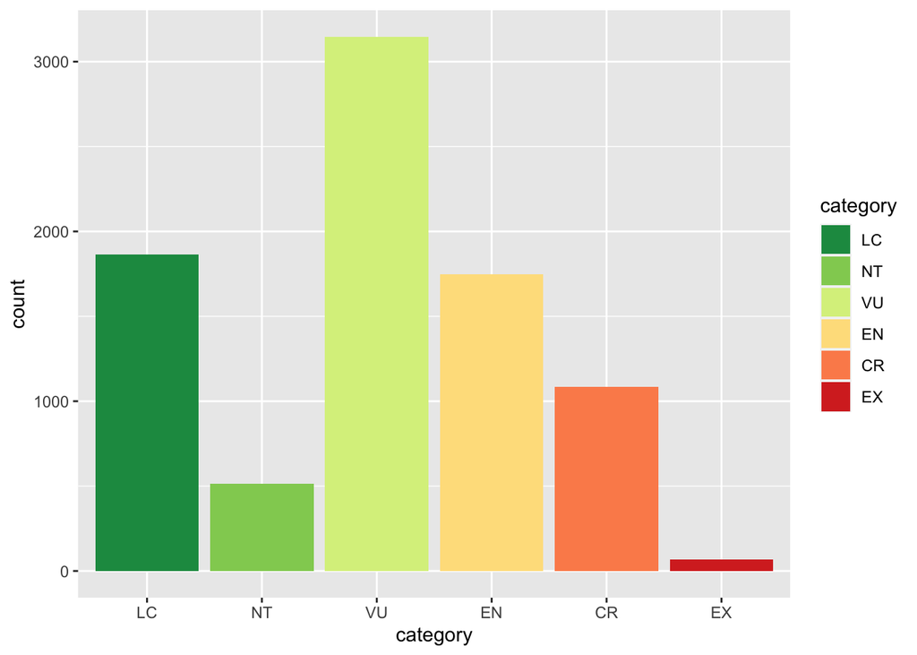

```r
page_stem <- 'api/v3/species/page/%s?token=%s'
page_end <- sprintf(page_stem, 1, api_key) ### multiple variables into format string
page_url <- file.path(domain_name, page_end)

spp_page1 <- fromJSON(page_url)

### convert extinction risk into factor and plot counts
spp_df <- spp_page1$result %>%
  mutate(category = factor(category, levels = c('LC', 'NT', 'VU', 'EN', 'CR', 'EX'))) %>%
  filter(!is.na(category)) #any category that is na will be dropped out

ggplot(spp_df) +
  geom_bar(aes(x = category, fill = category)) +
  scale_fill_brewer(palette = 'RdYlGn', direction = -1)
```

### Get Historic Assessments

historic assessments endpoint: `/api/v3/species/history/name/:name?token='YOUR TOKEN'`

```r
hist_stem <- 'api/v3/species/history/name/%s?token=%s'
spp <- 'Dermochelys coriacea'
hist_end <- sprintf(hist_stem, spp, api_key)
hist_url <- file.path(domain_name, hist_end)

spp_hist <- fromJSON(hist_url)

spp_hist_df <- spp_hist$result
```

### Pull threats and narrative, and extract information on gear types

Threats: `/api/v3/threats/species/name/:name?token='YOUR TOKEN'` Narratives: `/api/v3/species/narrative/:name?token='YOUR TOKEN'`

```r
threats_stem <- 'api/v3/threats/species/name/%s?token=%s'
thr_url <- file.path(domain_name, sprintf(threats_stem, spp, api_key))
spp_thr <- fromJSON(thr_url)$result

narratives_stem <- 'api/v3/species/narrative/%s?token=%s'
narr_url <- file.path(domain_name, sprintf(narratives_stem, spp, api_key))
spp_narr <- fromJSON(narr_url)$result

spp_narr$threats
```

```
## [1] "<p>Threats to Leatherbacks vary in time and space, and in relative impact to populations. Threat categories affecting marine turtles, including Leatherbacks, were described by Wallace <em>et al</em>. (2011) as:</p>  <p>1) Fisheries bycatch: incidental capture of marine turtles in fishing gea…
```

## Map threatened status

Goal: per cell, calculate proportion of species considered threatened (IUCN Red List VU, EN, CR). Here, I have assembled information from the IUCN API on species names and threatened status (among other details). This is data I have used for my own research, so some columns are particular to my research needs, but not for the purposes of this lab.

I have also assembled and filtered information from AquaMaps species distributions to focus only on species present off the coast of California, including species IDs, species scientific binomial (genus species), and probability of occurrence in various cells noted by a cell ID code, LOICZID.

### Read in all the info!

Read in info, and time permitting, challenge students to think of how they would assemble species info, spatial info, and extinction risk info. Choose a probability threshold for which species to count as “present”

```r
iucn_spp_info <- read_csv(here('data/iucn_marine_spp_info_2021-3.csv'))
iucn_spp_info$cat %>% unique()
```

```
## [1] "vu" "cr" "nt" "lc" "dd" "en" "ex"
```

```r
cell_ids <- read_csv(here('data/am_latlong.csv'))
spp_cells <- read_csv(here('data/am_spp_cells.csv'))
spp_ids <- read_csv(here('data/am_spp_ids.csv'))
```

```r
spp_risk_cells <- spp_cells %>%
  inner_join(cell_ids, by ="loiczid") %>%
  inner_join(spp_ids, by = "am_sid") %>%
  inner_join(iucn_spp_info, by = c("binomial" = "sciname"))

threatened_pct_cells <- spp_risk_cells %>%
  filter(prob >= 0.5) %>%
  mutate(threatened = (tolower(cat) %in% c('vu', "en", "cr", "exx"))) %>%
  filter(cat != 'dd') %>%
  group_by(lon, lat) %>%
  summarize(pct_threatened = sum(threatened) / n())
```

### Convert cells into a raster object

If we wished to do spatial analysis with this lat-long map of percent threatened species, we can convert our grid to a raster. Don’t forget to tell it our CRS, which since we are using lat-long data, we can use WGS84, EPSG code 4326.

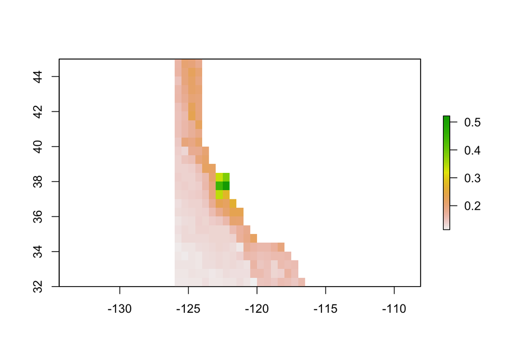

```r
spp_risk_rast <- rasterFromXYZ(threatened_pct_cells)
crs(spp_risk_rast) <- 4326

plot(spp_risk_rast)
```

### Plot with ggplot

`ggplot2::geom_raster` does not actually plot `raster` format objects, but gridded data in a dataframe with values that can be assigned to x and y. If we had data with a native `raster` format, we could convert to a `data.frame` (the reverse of `rasterFromXYZ`) using `as.data.frame(r, xy = TRUE)` - but we already have that in the form of threatened_pct_cells, so let’s see if they are different!

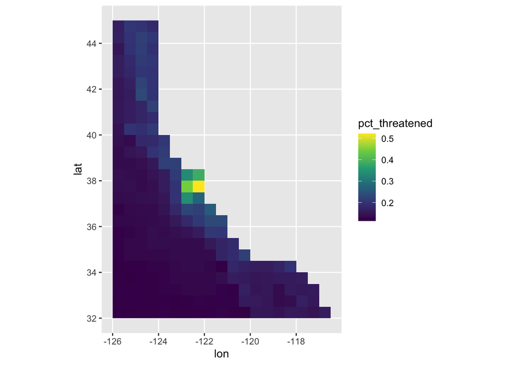

```r
spp_risk_rast_df <- spp_risk_rast %>%
  as.data.frame(xy = TRUE)
### Why does this have different length than threatened_pct_cells?

#TO GGPLOT A RASTER USE GEOM_RASTER BUT IT TAKES IN A DATAFRAME NOT A RASTER

ggplot(threatened_pct_cells) +
  geom_raster(aes(x = lon, y = lat, fill = pct_threatened)) +
  scale_fill_viridis_c() +
  coord_sf()
```

### Let’s finalize our map by overlaying a continent shape

We will use vector data from Natural Earth, using the `rnaturalearth` package. To get higher resolution vector data of global countries, install the `rnaturalearthdata` and `rnaturalearthhires` packages too.

Note, we can access individual countries, or continents, or states; but we probably also want to crop the resulting geometry down to just our area of focus. Because we made a raster object from our grid of data, we can use that as our crop bounding box.

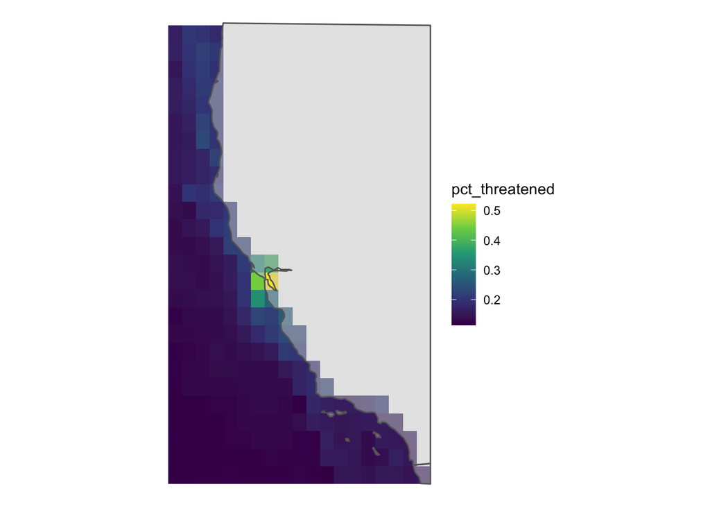

```r
land_sf <- rnaturalearth::ne_countries(scale = 50, ### start with 110
                                       country = c('united states of america', 'mexico'),
                                       returnclass = 'sf')
# plot(land_sf %>% select(geometry))
# st_crs(land_sf)

land_sf_cropped <- land_sf %>%
  st_crop(spp_risk_rast)

ggplot() +
  geom_raster(data = threatened_pct_cells, aes(x = lon, y = lat, fill = pct_threatened)) +
  geom_sf(data = land_sf_cropped, fill = 'grey80', color = 'grey40', alpha = .5) +
  scale_fill_viridis_c() +
  coord_sf() +
  theme_void()
```